# Análisis De Correspondencias

Wilson Sandoval Rodríguez

2024-02-23

# El análisis de correspondencias simples (ACS)

- Se utiliza para describir tablas de contingencia (TC) mediante la representación geométrica de las tablas de condicionales fila y columna (perfiles) derivadas de aquellas.
- El objetivo del ACS es describir las asociaciones entre las variables fila y columna, a través de sus perfiles:
- Comparar los perfiles fila.
- Comparar los perfiles columna.
- Estudiar las correspondencias entre perfiles fila y columna
- **Tabla de contingencia:** En estadística las tablas de contingencia se emplean para registrar y analizar la asociación entre dos o más variables, habitualmente de naturaleza cualitativa (nominales u ordinales).

La metodología la desarrolló Benzecri, a principios de los años 60 del siglo XX en la Universidad de Renner (Francia). En esencia. es un tipo especial de análisis de componentes principales pero realizado sobre una tabla de contingencia y usando una distancia euclídea ponderada llamada chi-cuadrado

**Ejemplo:** supongamos 400 tiendas de discos repartidas entre los países de la U.E. Se clasifica a los compradores en 3 categorías distintas: Jóvenes, Edad Media, Mayores, y a los tipos de música en 5 tipos:

- **A** = Música disco
- **B** = Rock’n’roll y música americana
- **C** = Pop y música inglesa (melódicas)
- **D** = Jazz y música autóctona
- **E** = Clásica

$$\begin{array}{ccccc}
& \text { Jov } & \text { Med } & \text { May } & \text
{ Total } \\
\text { A } & 70 & 0 & 0 & 70 \\
\text { B } & 45 & 45 & 0 & 90 \\
\text { C } & 30 & 30 & 30 & 90 \\
\text { D } & 0 & 80 & 20 & 100 \\
\text { E } & 35 & 5 & 10 & 50 \\
\text { Total } & 180 & 160 & 60 & 400
\end{array}$$

- Se define el perfil de una tabla como el conjunto de las frecuencias de una fila o de una columna dividido entre el total de la fila o columna.

$$\begin{array}{cccc}
& \text { Jov } & \text { Med } & \text { May } \\
\text { A } & 1 & 0 & 0 \\
\text { B } & 0.5 & 0.5 & 0 \\
\text { C } & 0.33 & 0.33 & 0.33 \\
\text { D } & 0 & 0.8 & 0.2 \\
\text { E } & 0.7 & 0.1 & 0.2 \\
\text { Total } & 0.45 & 0.40 & 0.15
\end{array}$$

- Se puede ver que un
  - 45% de compradores es Joven,
  - 40 % Medianos y
  - 15% Mayores.
- Por tipos de música, por ejemplo en el tipo E el reparto de edades difiere de la media: (70% frente a 45% en Jóvenes, 10% frente a 40% en Medianos).

Si nos centramos en las columnas

$$\begin{array}{lcccc}
& \text { Jov } & \text { Med } & \text { Mayores} &
\text { Total } \\
\text { A } & 0.39 & 0 & 0 & 0.175 \\
\text { B } & 0.25 & 0.28 & 0 & 0.225 \\
\text { C } & 0.17 & 0.19 & 0.50 & 0.225 \\
\text { D } & 0 & 0.50 & 0.33 & 0.25 \\
\text { E } & 0.19 & 0.03 & 0.17 & 0.125
\end{array}$$

Por ejemplo de los 160 compradores en el caso de los de mediana edad, un 50% compra el tipo de música $D$ en vez del porcentaje general del 25%.

### Contraste Chi cuadrado

La prueba de chi-cuadrado es un método estadístico que se utiliza para determinar si existe una asociación significativa entre variables categóricas comparando las frecuencias observadas y esperadas en una tabla de contingencia.

$H_0$ : No hay asociación significativa entre las variables.

$H_1$: Hay una asociación significativa entre las variables.

Para realizar la prueba Chi-cuadrado:

- Crear una tabla de contingencia con las frecuencias observadas para cada categoría.
- Calcular las frecuencias esperadas asumiendo la independencia entre las variables.
- Calcular el estadístico Chi-cuadrado.
- Comparar el estadístico calculado con el valor crítico de la distribución Chi-cuadrado para determinar si se rechaza o no la hipótesis nula.

$$\chi^2 = \sum \frac {(O_{ij} -
E_{ij})^2}{E_{ij}}$$
Dónde:

- χ2 : El estadístico de prueba chi-cuadrado, que mide la discrepancia entre los valores observados y esperados.
- $\Sigma$ (sigma) : suma los valores de cada celda de la tabla de contingencia.
- $O_{ij}$ : La frecuencia observada en cada celda de la tabla de contingencia.
- $E_{ij}$ : La frecuencia esperada en cada celda de la tabla de contingencia.

Casos de uso de ejemplo

- Evaluar la relación entre las variables demográficas (por ejemplo, edad, género, ingresos) y las preferencias del consumidor o el comportamiento de compra.
- Examinar la asociación entre los factores de riesgo y los resultados de las enfermedades, como el tabaquismo y la incidencia el cáncer de pulmón.
- Explorar la relación entre variables categóricas como el nivel educativo y la situación laboral o la afiliación política y el comportamiento electoral.
- Determinar si los patrones de herencia observados son consistentes con las proporciones mendelianas esperadas, o si ciertos marcadores genéticos están asociados con rasgos o enfermedades específicas.
- Evaluar la relación entre las variables de control de calidad, como el tipo de defecto, y la línea de producción.

### Suposiciones

**1. Independencia:** La ocurrencia de una observación no debe influir ni ser influenciada por otra observación.

**2. Categórico:** Ambas variables son para datos categóricos.

**3. Mutuamente excluyentes:** Las observaciones sólo pueden pertenecer a una celda de la tabla de contingencia.

**4. Tamaño de la muestra:** Debe haber al menos cinco observaciones en cada celda de la tabla de contingencia.

### Pruebas alternativas

- **Prueba exacta de Fisher:** adecuada cuando el tamaño de la muestra es pequeño y las frecuencias de celda esperadas en la tabla de contingencia son inferiores a 5. A menudo se utiliza como alternativa a la prueba de chi-cuadrado en tablas de contingencia de 2x2.
- **Prueba de McNemar:** se utiliza al analizar datos categóricos emparejados, generalmente en una tabla de contingencia de 2x2, donde las observaciones son dependientes o están relacionadas. Se utiliza comúnmente en estudios de antes y después o en estudios de casos y controles emparejados.
- **Prueba de Cochran-Mantel-Haenszel:** se utiliza al analizar datos categóricos en estudios estratificados o emparejados. Permite la comparación de múltiples tablas de contingencia 2x2 mientras controla variables de confusión o factores de estratificación.

## Cálculo paso a paso de las estadísticas de la prueba de chi-cuadrado

ejemplo con los datos. Datos de COVID Y usaremos la prueba de Chi-cuadrado para ver si ciertos síntomas de COVID y el ingreso en UCI están relacionados.

$$\begin{array}{|l|c|c|c|}
\hline
& \textbf{Anorexia} & \textbf{No-anorexia} & \textbf{Total}
\\ \hline
\textbf{UCI} & 24 & 12 &
36 \\ \hline
\textbf{No-UCI} & 31 & 71 &
102 \\ \hline
\textbf{Total} & 55 & 83 &
138 \\ \hline
\end{array}$$

Cargar las librerias

```r
library("factoextra")
library("FactoMineR")
library("gplots")
library("dplyr")
```

Tabla de contingencias observadas

```r
O=matrix(c(24,12,31,71), nrow = 2, byrow = T)


colnames(O)=c("Anorexia", "No Anorexia")

rownames(O)=c("UCI", "No UCI")
O
```

```
##        Anorexia No Anorexia
## UCI          24          12
## No UCI       31          71
```

### Tabla de valores Esperados

Los valores esperados son el número de observaciones que se podría esperar que ocurran, en promedio, si las proporciones de la prueba fueran verdaderas.

El valor esperado en una tabla de contingencia se refiere a lo que uno esperaría si las variables fueran independientes, es decir, si no hubiera relación entre ellas. Para calcular los valores esperados en una tabla de contingencia, se utiliza la siguiente fórmula:

$$E_{ij}=\frac{R_iC_j}{N}$$

donde: - $E_{ij}$ es el valor esperado para la celda en la fila i y columna j.

- $R_i$ es el total de la fila i.
- $C_j$ es el total de la columna j.
- $N$ es el total general de todas las observaciones en la tabla.

```r
#library(sjPlot)
#library(sjmisc)
#library(sjlabelled)
library(kableExtra)
```

```r
O_chisq = chisq.test(O)
```

```r
kable(addmargins(O_chisq$expected))
```

|  | Anorexia | No Anorexia | Sum |
| --- | --- | --- | --- |
| UCI | 14.34783 | 21.65217 | 36 |
| No UCI | 40.65217 | 61.34783 | 102 |
| Sum | 55.00000 | 83.00000 | 138 |

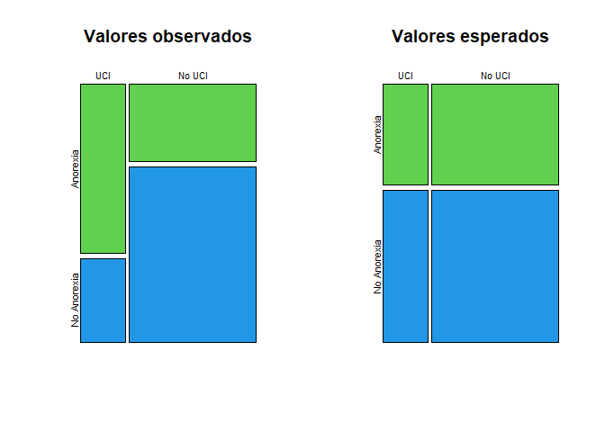

```r
par(mfrow = c(1, 2))

mosaicplot(O,  col = 3:5, main= "Valores observados",)
mosaicplot(O_chisq$expected, col = 3:5, main= "Valores esperados")
```

prueba chi cuadrado

```r
O_chisq = chisq.test(O,correct = F)
O_chisq
```

```
##
##  Pearson's Chi-squared test
##
## data:  O
## X-squared = 14.606, df = 1, p-value = 0.0001325
```

```r
O_chisq$expected
```

```
##        Anorexia No Anorexia
## UCI    14.34783    21.65217
## No UCI 40.65217    61.34783
```

```r
library(vcd)
assocstats(O)
```

```
##                     X^2 df   P(> X^2)
## Likelihood Ratio 14.472  1 0.00014225
## Pearson          14.606  1 0.00013246
##
## Phi-Coefficient   : 0.325
## Contingency Coeff.: 0.309
## Cramer's V        : 0.325
```

## Parte 2

Análisis de correspondencia

```r
library("gplots")  # tabla de cotingencia plot
```

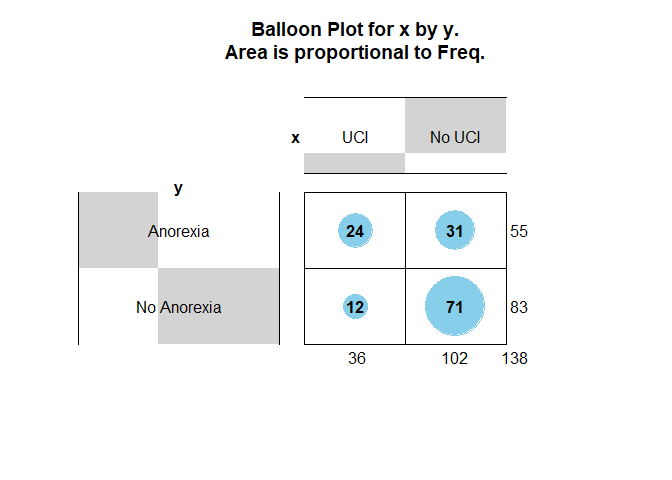

```r
balloonplot(as.table(O),label=T)
```

El tama?o del punto indica la relaci?n

## Ejemplo $1$

```r
data("housetasks")
housetasks%>%head(15)%>%DT::datatable()
```

|  | Wife | Alternating | Husband | Jointly |
| --- | --- | --- | --- | --- |
| Laundry | 156 | 14 | 2 | 4 |
| Main_meal | 124 | 20 | 5 | 4 |
| Dinner | 77 | 11 | 7 | 13 |
| Breakfeast | 82 | 36 | 15 | 7 |
| Tidying | 53 | 11 | 1 | 57 |
| Dishes | 32 | 24 | 4 | 53 |
| Shopping | 33 | 23 | 9 | 55 |
| Official | 12 | 46 | 23 | 15 |
| Driving | 10 | 51 | 75 | 3 |
| Finances | 13 | 13 | 21 | 66 |

[output cut: 3 more lines]

convertir la data como una tabla

```r
df<-as.table(as.matrix(housetasks))
df
```

```
##            Wife Alternating Husband Jointly
## Laundry     156          14       2       4
## Main_meal   124          20       5       4
## Dinner       77          11       7      13
## Breakfeast   82          36      15       7
## Tidying      53          11       1      57
## Dishes       32          24       4      53
## Shopping     33          23       9      55
## Official     12          46      23      15
## Driving      10          51      75       3
## Finances     13          13      21      66
## Insurance     8           1      53      77
## Repairs       0           3     160       2
## Holidays      0           1       6     153
```

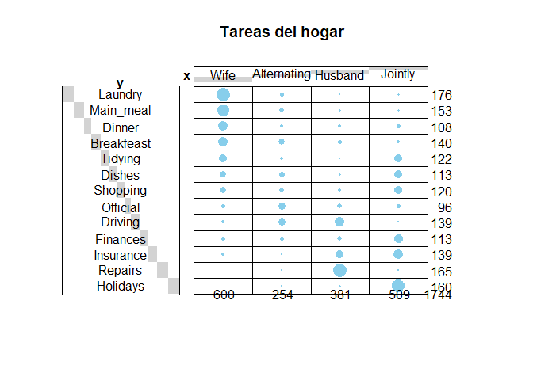

```r
balloonplot(t(df), label=F, main="Tareas del hogar")
```

## Prueba chi cuadrado

(prueba de hipotesis)

$H_0:$ variables independientes (hipótesis nula)

$H_1:$ variables son dependientes (hipopteis alternativa)

```r
class(housetasks)
```

```
## [1] "data.frame"
```

```r
class(housetasks$Jointly)
```

```
## [1] "integer"
```

prueba chicuadrado

```r
chisq.test(housetasks)
```

```
##
##  Pearson's Chi-squared test
##
## data:  housetasks
## X-squared = 1944.5, df = 36, p-value < 2.2e-16
```

p valor.

$valor\ p = 2.2e-16$ $2.2\times10^{-16}$

$valor \ p= 2.2e-16 <0.05$

se rechaza la hipotesis nula en favor de la alternativa,

Las parejas se organizan para hacer las tareas del hogar

## Analisis de correspondencia

```r
housetasks_CA= CA(housetasks, graph = F)
print(housetasks_CA)
```

```
## **Results of the Correspondence Analysis (CA)**
## The row variable has  13  categories; the column variable has 4 categories
## The chi square of independence between the two variables is equal to 1944.456 (p-value =  0 ).
## *The results are available in the following objects:
##
##    name              description
## 1  "$eig"            "eigenvalues"
## 2  "$col"            "results for the columns"
## 3  "$col$coord"      "coord. for the columns"
## 4  "$col$cos2"       "cos2 for the columns"
## 5  "$col$contrib"    "contributions of the columns"
## 6  "$row"            "results for the rows"
## 7  "$row$coord"      "coord. for the rows"
## 8  "$row$cos2"       "cos2 for the rows"
## 9  "$row$contrib"    "contributions of the rows"
## 10 "$call"           "summary called parameters"
## 11 "$call$marge.col" "weights of the columns"
## 12 "$call$marge.row" "weights of the rows"
```

```r
housetasks_CA$col
```

```
## $coord
##                   Dim 1      Dim 2       Dim 3
## Wife        -0.83762154  0.3652207 -0.19991139
## Alternating -0.06218462  0.2915938  0.84858939
## Husband      1.16091847  0.6019199 -0.18885924
## Jointly      0.14942609 -1.0265791 -0.04644302
##
## $contrib
##                 Dim 1     Dim 2      Dim 3
## Wife        44.462018 10.312237 10.8220753
## Alternating  0.103739  2.782794 82.5492464
## Husband     54.233879 17.786612  6.1331792
## Jointly      1.200364 69.118357  0.4954991
##
## $cos2
##                   Dim 1     Dim 2       Dim 3
## Wife        0.801875947 0.1524482 0.045675847
## Alternating 0.004779897 0.1051016 0.890118521
## Husband     0.772026244 0.2075420 0.020431728
## Jointly     0.020705858 0.9772939 0.002000236
##
## $inertia
## [1] 0.3010185 0.1178242 0.3813729 0.3147248
```

```r
housetasks_CA$row
```

```
## $coord
##                 Dim 1      Dim 2       Dim 3
## Laundry    -0.9918368  0.4953220 -0.31672897
## Main_meal  -0.8755855  0.4901092 -0.16406487
## Dinner     -0.6925740  0.3081043 -0.20741377
## Breakfeast -0.5086002  0.4528038  0.22040453
## Tidying    -0.3938084 -0.4343444 -0.09421375
## Dishes     -0.1889641 -0.4419662  0.26694926
## Shopping   -0.1176813 -0.4033171  0.20261512
## Official    0.2266324  0.2536132  0.92336416
## Driving     0.7417696  0.6534143  0.54445849
## Finances    0.2707669 -0.6178684  0.03479681
## Insurance   0.6470759 -0.4737832 -0.28936051
## Repairs     1.5287787  0.8642647 -0.47208778
## Holidays    0.2524863 -1.4350066 -0.12958665
##
## $contrib
##                 Dim 1      Dim 2       Dim 3
## Laundry    18.2867003  5.5638913  7.96842443
## Main_meal  12.3888433  4.7355230  1.85868941
## Dinner      5.4713982  1.3210221  2.09692603
## Breakfeast  3.8249284  3.6986131  3.06939857
## Tidying     1.9983518  2.9656441  0.48873403
## Dishes      0.4261663  2.8441170  3.63429434
## Shopping    0.1755248  2.5151584  2.22335679
## Official    0.5207837  0.7956201 36.94038942
## Driving     8.0778371  7.6468564 18.59638635
## Finances    0.8750075  5.5585460  0.06175066
## Insurance   6.1470616  4.0203590  5.25263863
## Repairs    40.7300940 15.8806509 16.59639139
## Holidays    1.0773030 42.4539986  1.21261994
##
## $cos2
##                 Dim 1      Dim 2       Dim 3
## Laundry    0.73998741 0.18455213 0.075460467
## Main_meal  0.74160285 0.23235928 0.026037873
## Dinner     0.77664011 0.15370323 0.069656660
## Breakfeast 0.50494329 0.40023001 0.094826699
## Tidying    0.43981243 0.53501508 0.025172490
## Dishes     0.11811778 0.64615253 0.235729693
## Shopping   0.06365362 0.74765514 0.188691242
## Official   0.05304464 0.06642648 0.880528877
## Driving    0.43201860 0.33522911 0.232752289
## Finances   0.16067678 0.83666958 0.002653634
## Insurance  0.57601197 0.30880208 0.115185951
## Repairs    0.70673575 0.22587147 0.067392778
## Holidays   0.02979239 0.96235977 0.007847841
##
## $inertia
##  [1] 0.13415976 0.09069235 0.03824633 0.04112368 0.02466697 0.01958732
##  [7] 0.01497017 0.05330000 0.10150885 0.02956446 0.05793584 0.31287411
## [13] 0.19631064
```

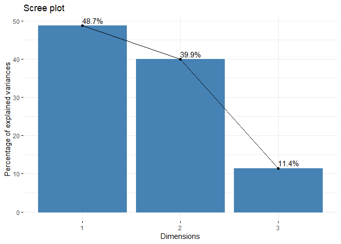

```r
fviz_screeplot(housetasks_CA, addlabel=T)
```

El 89% de la varianzaa de las variables estan eplicadaas por las dimensiones $1$ y $2$

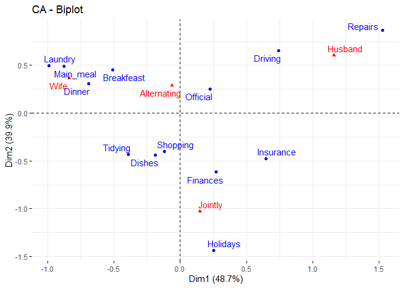

```r
fviz_ca_biplot(housetasks_CA,repel = T)
```

- Azul: filas
- rojo: columnas
- tareas como dinner, breafesast, laundry son realizadas con mas frecuencia por la esposa.
- De las tareas Driving y repairs se encarga con mayor frecuencia el esposo.
- juntos: holidays, finances, seguridad
- alternan: Official

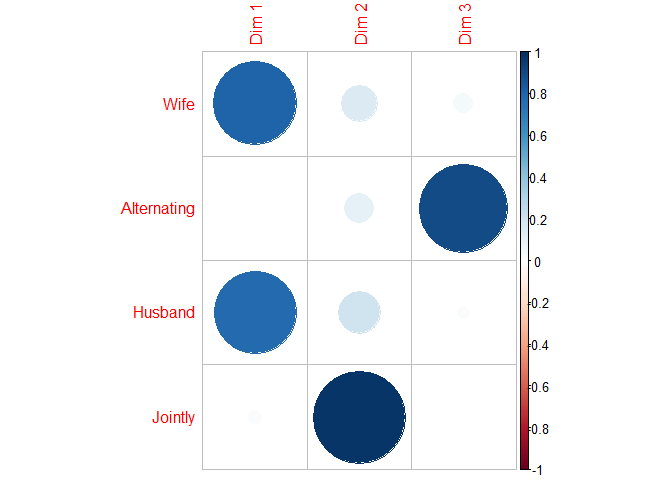

```r
library("corrplot")
corrplot(housetasks_CA$col$cos2)
```

distancia $cos^2$ para la variable de tareas

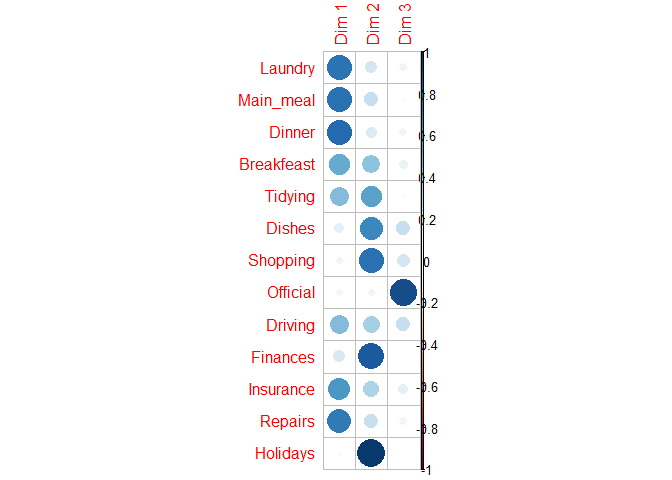

```r
corrplot(housetasks_CA$row$cos2 )
```

- Componente $1$: tareas individuales realizadas dentro del hogar
- Componente $2$: tareas realizadas en conjunto dentro del hogar

Contribucion de cada asignacion de responsabilidad

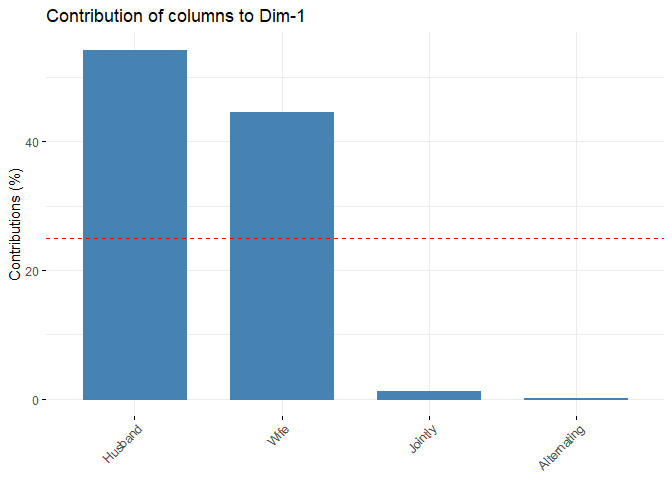

```r
fviz_contrib(housetasks_CA, choice = "col" ,axes = 1)
```

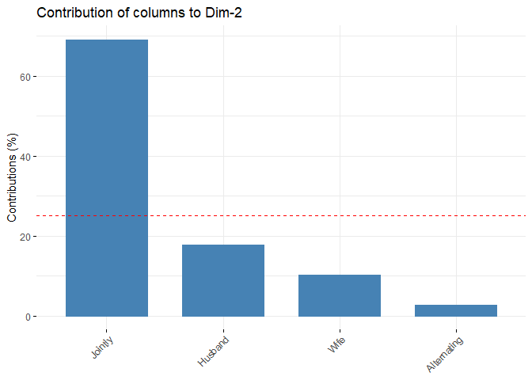

```r
fviz_contrib(housetasks_CA, choice = "col" ,axes = 2)
```

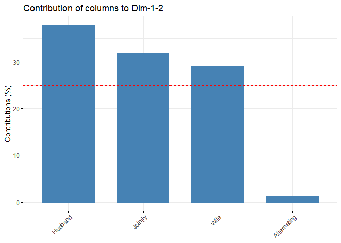

```r
fviz_contrib(housetasks_CA, choice = "col" ,axes = 1:2)
```

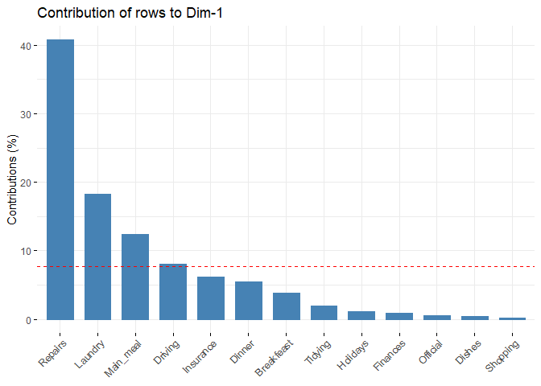

```r
fviz_contrib(housetasks_CA, choice = "row" ,axes = 1)
```

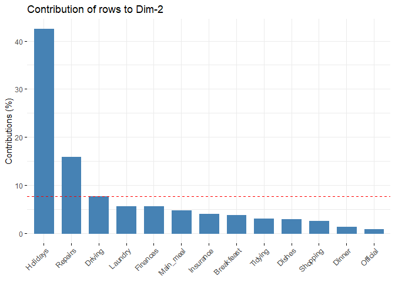

```r
fviz_contrib(housetasks_CA, choice = "row" ,axes = 2)
```

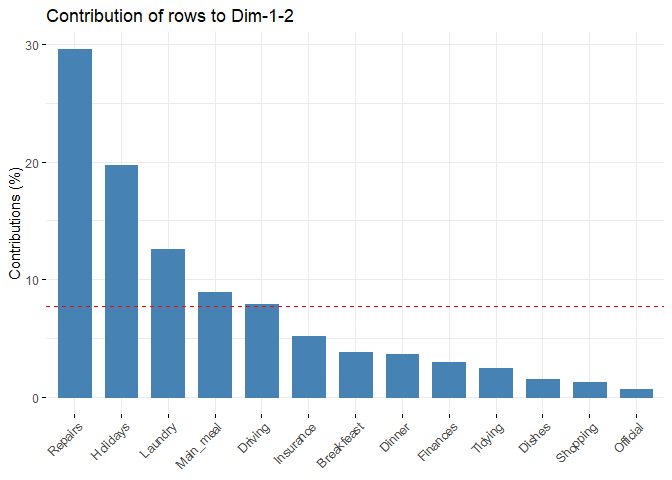

```r
fviz_contrib(housetasks_CA, choice = "row" ,axes = 1:2)
```

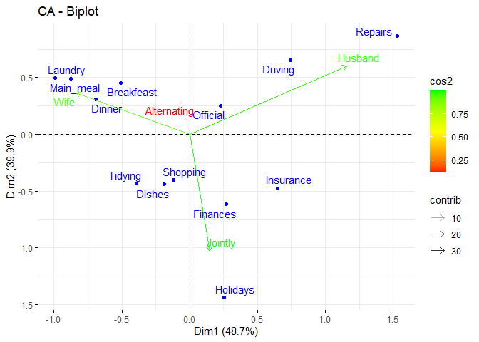

```r
fviz_ca_biplot(housetasks_CA,repel = T, arrow=c(F,T), col.col="cos2", gradient.cols=c("red", "yellow", "green"), alpha.col="contrib")
```